# NitratiruptorRNA_seq

Angela Ares

September 29, 2021

by adding `fig.path = 'figures/'` we put all of the figures created when we knit this document into a directory called `figures`

# 1 Differential Expression Testing

Load Libraries:

```r
#library(tximport) Not available for version 3.6.0
library(DESeq2)
library(tidyverse)
library(dplyr)
library("GSEABase")
#library(clusterProfiler)
library(RColorBrewer)
library(pheatmap)
library(wesanderson)
library(org.EcK12.eg.db)
library(org.Sc.sgd.db)
library(GOstats)
library(edgeR)
library(treemap)
library(tidyverse)
library(ggplot2)
library(AnnotationDbi)
library(gage)
library(ggraph)
library(clusterProfiler)
library(reshape2)
library(jcolors)
```

Load data

```r
sb<-read.csv("~/Documents/Projects OIST/HV/Transcriptome-STEM 2018-2021/RNA results/DESeq2/Nfcore_analysis/Data/matrixc1.csv", header = TRUE)
```

Define metadata

```r
treatment <- c("c","c","c","cd","cd","cu","cu")
strain <- c("SB155","SB155","SB155","SB155","SB155","SB155","SB155")
sample<-c("c1","c2","c3","cd1","cd2","cu1","cu2")
gensmeta<- data.frame(strain, treatment, sample)
rownames(gensmeta)<-c("c1","c2","c3","cd1","cd2","cu1","cu2")
```

convert first column (refering name of genes) into rownames

```r
rownames(sb) <- sb[,1]
```

check type of variables and convert to integer

```r
sb[,-1]<- lapply(lapply(sb[,-1],round),as.integer)
str(sb)
```

```
## 'data.frame':    1992 obs. of  8 variables:
##  $ gene_id: Factor w/ 1992 levels "NIS_RS00005",..: 1973 1983 1969 1984 1 2 3 4 5 6 ...
##  $ c1     : int  0 0 0 0 2266 5686 13185 3002 1073 1932 ...
##  $ c2     : int  0 0 0 0 847 1799 4520 631 327 530 ...
##  $ c3     : int  0 0 0 0 2661 4185 9802 1275 963 1136 ...
##  $ cd1    : int  0 0 0 0 1038 1503 4492 694 339 340 ...
##  $ cd2    : int  0 0 0 0 876 1372 3439 613 262 313 ...
##  $ cu1    : int  0 0 0 0 1316 2642 11633 1462 676 2267 ...
##  $ cu2    : int  0 0 0 0 777 1300 5309 305 267 1062 ...
```

```r
sbf<- sb[, -1]
```

make sure the colnames and rownames are the same in both data.frames ("sbf" and "gensmeta")

```r
all(rownames(gensmeta)==colnames(sbf))
```

```
## [1] TRUE
```

Make DESeq object

```r
dds<- DESeqDataSetFromMatrix(countData = sbf,
                             colData = gensmeta,
                             design = ~ treatment)
dds$treatment<- relevel(dds$treatment, ref = "c")
```

Run DESeq2:

```r
dds_df <- DESeq(dds)
```

DEG results

```r
res<- results(dds_df, alpha = 0.05)
```

Check out results:

```r
cd_res<- results(dds_df, contrast = c("treatment", "cd", "c"), alpha = 0.05)
cu_res<- results(dds_df, contrast = c("treatment", "cu", "c"), alpha = 0.05)
head(cd_res)
```

```
## log2 fold change (MLE): treatment cd vs c
## Wald test p-value: treatment cd vs c
## DataFrame with 6 rows and 6 columns
##                     baseMean     log2FoldChange             lfcSE
##                    <numeric>          <numeric>         <numeric>
## NIS_RS10240                0                 NA                NA
## NIS_RS10290                0                 NA                NA
## NIS_RS10220                0                 NA                NA
## NIS_RS10295                0                 NA                NA
## NIS_RS00005 1306.37506184946   0.47548071339419 0.324809463031445
## NIS_RS00010 2315.76543108861 0.0710375169282024 0.271133365040941
##                          stat            pvalue              padj
##                     <numeric>         <numeric>         <numeric>
## NIS_RS10240                NA                NA                NA
## NIS_RS10290                NA                NA                NA
## NIS_RS10220                NA                NA                NA
## NIS_RS10295                NA                NA                NA
## NIS_RS00005  1.46387580262142 0.143227885949457 0.281762107314672
## NIS_RS00010 0.262002121787836    0.793319806367 0.880429432164161
```

```r
head(cu_res)
```

```
## log2 fold change (MLE): treatment cu vs c
## Wald test p-value: treatment cu vs c
## DataFrame with 6 rows and 6 columns
##                     baseMean     log2FoldChange            lfcSE
##                    <numeric>          <numeric>        <numeric>
## NIS_RS10240                0                 NA               NA
## NIS_RS10290                0                 NA               NA
## NIS_RS10220                0                 NA               NA
## NIS_RS10295                0                 NA               NA
## NIS_RS00005 1306.37506184946 -0.561625148715013  0.3248013035651
## NIS_RS00010 2315.76543108861 -0.690336229384722 0.27089516910043
##                          stat             pvalue               padj
##                     <numeric>          <numeric>          <numeric>
## NIS_RS10240                NA                 NA                 NA
## NIS_RS10290                NA                 NA                 NA
## NIS_RS10220                NA                 NA                 NA
## NIS_RS10295                NA                 NA                 NA
## NIS_RS00005 -1.72913452794208 0.0837850208056454  0.150889205650894
## NIS_RS00010 -2.54835193878556 0.0108233219779183 0.0278816655894097
```

visualize the dispersion (ver primer script)

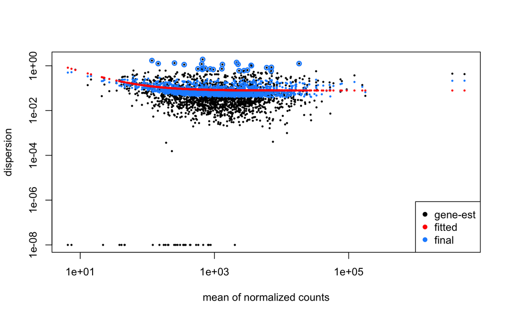

```r
plotDispEsts(dds_df)
```

DEG result

```r
res<- results(dds_df, alpha = 0.05)
```

Summarize results, up and down regulated genes are indicated

```r
summary(cd_res, alpha=0.05)
```

```
##
## out of 1988 with nonzero total read count
## adjusted p-value < 0.05
## LFC > 0 (up)       : 282, 14%
## LFC < 0 (down)     : 233, 12%
## outliers [1]       : 7, 0.35%
## low counts [2]     : 0, 0%
## (mean count < 7)
## [1] see 'cooksCutoff' argument of ?results
## [2] see 'independentFiltering' argument of ?results
```

```r
summary(cu_res, alpha=0.05)
```

```
##
## out of 1988 with nonzero total read count
## adjusted p-value < 0.05
## LFC > 0 (up)       : 401, 20%
## LFC < 0 (down)     : 444, 22%
## outliers [1]       : 7, 0.35%
## low counts [2]     : 0, 0%
## (mean count < 7)
## [1] see 'cooksCutoff' argument of ?results
## [2] see 'independentFiltering' argument of ?results
```

# 2 Visualizing RNA-seq results

## 2.1 Normalization

**Count Data Transformations:** for ranking and visualizations (e.g. PCA plots and heatmaps)

**rlog**

```r
rld <- rlog(dds, blind=TRUE)
head(assay(rld), 30)
```

```
##                    c1        c2        c3       cd1       cd2       cu1
## NIS_RS10240  0.000000  0.000000  0.000000  0.000000  0.000000  0.000000
## NIS_RS10290  0.000000  0.000000  0.000000  0.000000  0.000000  0.000000
## NIS_RS10220  0.000000  0.000000  0.000000  0.000000  0.000000  0.000000
## NIS_RS10295  0.000000  0.000000  0.000000  0.000000  0.000000  0.000000
## NIS_RS00005 10.182849 10.197160 10.519098 10.574951 10.586286  9.944663
## NIS_RS00010 11.294335 11.175168 11.257992 11.245577 11.320488 10.871915
## NIS_RS00015 12.654520 12.602075 12.627601 12.808403 12.741233 12.727628
## NIS_RS00020 10.204942  9.751905  9.723114 10.041292 10.090324  9.794863
## NIS_RS00025  8.954620  8.810113  9.078699  9.049325  8.989299  8.765612
## NIS_RS00030  9.797166  9.572042  9.587979  9.443333  9.516448 10.110060
## NIS_RS00035  8.562387  8.294109  8.223111  8.260733  8.450563  8.495766
## NIS_RS00040  5.921270  5.526115  5.706041  5.253945  5.405288  5.350406
## NIS_RS00045 10.570164 10.456446 10.348711 10.933782 10.859236 10.329709
## NIS_RS00050  9.166692  9.409600  9.374421  9.746958  9.635546  8.593094
## NIS_RS00055 12.107878 11.620514 11.676200 11.388347 11.413743 11.292684
## NIS_RS00060 11.255651 10.765908 10.799220 10.384319 10.347782 10.745921
## NIS_RS00065 11.719859 12.511874 12.199422 12.730926 12.693815 12.635961
## NIS_RS00070 10.582094 11.623963 11.105188 11.652017 11.700131 11.401955
## NIS_RS00075 10.718603 11.625049 11.297355 11.660824 11.598598 11.431883
## NIS_RS00080 11.191158 12.044263 11.856496 12.476548 12.484576 12.323685
## NIS_RS00085 12.913715 13.934268 13.596895 14.502511 14.451920 13.495093
## NIS_RS00090 10.513354 10.670833 10.648636 10.934325 10.871763  9.604528
## NIS_RS00095  7.928610  7.241281  7.564640  6.238309  6.383925  6.719170
## NIS_RS00100  8.964705  8.500960  8.815285  8.057094  7.852855  8.024473
## NIS_RS00105 11.172202 11.069296 11.392627 11.332039 11.269749 10.396455
## NIS_RS00110 13.054585 13.801504 13.877666 13.862835 13.753812 14.247588
## NIS_RS00115 11.991570 12.621496 12.703695 12.500934 12.446030 14.017910
## NIS_RS00120 11.350742 12.355762 12.119648 11.269722 11.259790 13.994333
## NIS_RS00125  7.268879  7.625605  7.219886  7.283713  7.228068  8.618557
## NIS_RS00130  6.828416  8.055588  7.615794  6.973570  7.288914  7.325044
##                   cu2
## NIS_RS10240  0.000000
## NIS_RS10290  0.000000
## NIS_RS10220  0.000000
## NIS_RS10295  0.000000
## NIS_RS00005 10.087357
## NIS_RS00010 10.883214
## NIS_RS00015 12.680350
## NIS_RS00020  9.204760
## NIS_RS00025  8.616435
## NIS_RS00030 10.081000
## NIS_RS00035  8.242522
## NIS_RS00040  5.896493
## NIS_RS00045 10.295456
## NIS_RS00050  8.641547
## NIS_RS00055 11.207546
## NIS_RS00060 10.375252
## NIS_RS00065 12.334907
## NIS_RS00070 11.267579
## NIS_RS00075 11.124061
## NIS_RS00080 11.529900
## NIS_RS00085 13.049970
## NIS_RS00090  9.439807
## NIS_RS00095  7.042382
## NIS_RS00100  8.218887
## NIS_RS00105 10.746591
## NIS_RS00110 14.402048
## NIS_RS00115 13.411305
## NIS_RS00120 12.972978
## NIS_RS00125  8.166884
## NIS_RS00130  7.725055
```

** Variance stabilizing transformation (so much faster than rlog):**

```r
vsd <- vst(dds, blind = TRUE)
head(assay(vsd), 20)
```

```
##                    c1        c2        c3       cd1       cd2       cu1
## NIS_RS10240  1.315041  1.315041  1.315041  1.315041  1.315041  1.315041
## NIS_RS10290  1.315041  1.315041  1.315041  1.315041  1.315041  1.315041
## NIS_RS10220  1.315041  1.315041  1.315041  1.315041  1.315041  1.315041
## NIS_RS10295  1.315041  1.315041  1.315041  1.315041  1.315041  1.315041
## NIS_RS00005 10.089175 10.115872 10.696424 10.793322 10.812933  9.622357
## NIS_RS00010 11.412478 11.199211 11.348109 11.326110 11.458768 10.623260
## NIS_RS00015 12.624392 12.526501 12.574379 12.903762 12.782944 12.758262
## NIS_RS00020 10.493338  9.693357  9.639637 10.214523 10.299597  9.773233
## NIS_RS00025  9.017961  8.753012  9.237650  9.187166  9.080863  8.669851
## NIS_RS00030  9.860259  9.443355  9.474200  9.191380  9.335306 10.403165
## NIS_RS00035  8.742984  8.258465  8.124811  8.195162  8.545286  8.624884
## NIS_RS00040  6.305025  5.620396  5.941392  5.077932  5.381632  5.297803
## NIS_RS00045 10.598152 10.388537 10.183932 11.232100 11.106189 10.147132
## NIS_RS00050  9.130634  9.567579  9.505389 10.138005  9.954287  7.959752
## NIS_RS00055 12.525874 11.696521 11.795384 11.268450 11.316579 11.083925
## NIS_RS00060 11.681352 10.849572 10.908666 10.131441 10.057704 10.813702
## NIS_RS00065 10.998824 12.600169 12.020406 12.980938 12.917723 12.817981
## NIS_RS00070  9.769839 11.849668 10.905396 11.897624 11.979178 11.460547
## NIS_RS00075 10.069393 11.838922 11.255022 11.900200 11.793565 11.500213
## NIS_RS00080 10.310265 12.093042 11.746101 12.836417 12.849707 12.580856
##                   cu2
## NIS_RS10240  1.315041
## NIS_RS10290  1.315041
## NIS_RS10220  1.315041
## NIS_RS10295  1.315041
## NIS_RS00005  9.905924
## NIS_RS00010 10.645442
## NIS_RS00015 12.671985
## NIS_RS00020  8.568301
## NIS_RS00025  8.379002
## NIS_RS00030 10.354716
## NIS_RS00035  8.161055
## NIS_RS00040  6.273623
## NIS_RS00045 10.079735
## NIS_RS00050  8.065060
## NIS_RS00055 10.914173
## NIS_RS00060 10.113719
## NIS_RS00065 12.277889
## NIS_RS00070 11.214815
## NIS_RS00075 10.925150
## NIS_RS00080 11.091928
```

## 2.2 Ordination

rlog PCA:

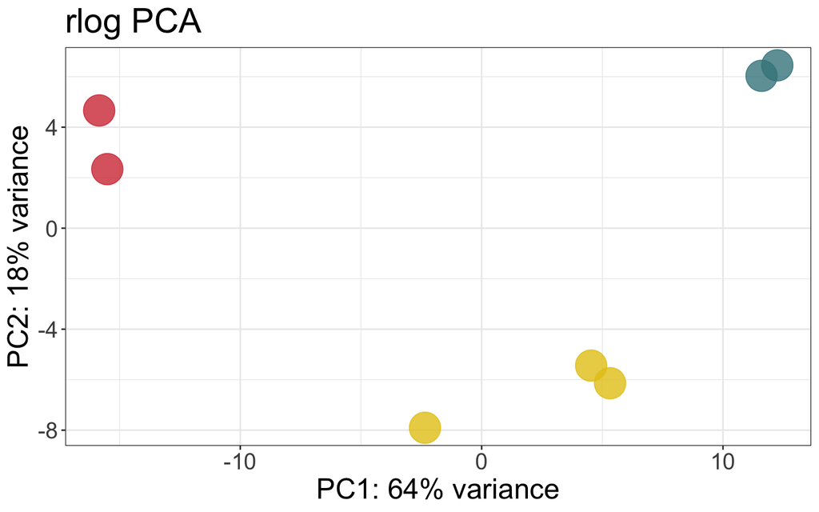

```r
data1 <- plotPCA(rld, intgroup = "treatment", returnData=TRUE)
data1$group<-gsub(" : ","_",as.character(data1$group))
percentVar1 <- round(100 * attr(data1, "percentVar"))

PCA<-ggplot(data1, aes(PC1, PC2, color = treatment))+ theme_bw()+
  geom_point(size=10, alpha = 0.8) + scale_colour_manual(values = c("#E5C616", "#42858C","#D33B44"))+
  xlab(paste0("PC1: ",percentVar1[1],"% variance")) +
  ylab(paste0("PC2: ",percentVar1[2],"% variance")) +
  theme(legend.position = "none")+
  theme(text = element_text(size=20)) + ggtitle("rlog PCA")
PCA
```

```r
#ggsave("desktop/PCA.pdf", device="pdf", width = 9, height = 5)
ggsave("rlogPCA.pdf", device="pdf", width = 7, height = 5) # to save the plot
```

variance stabilized PCA:

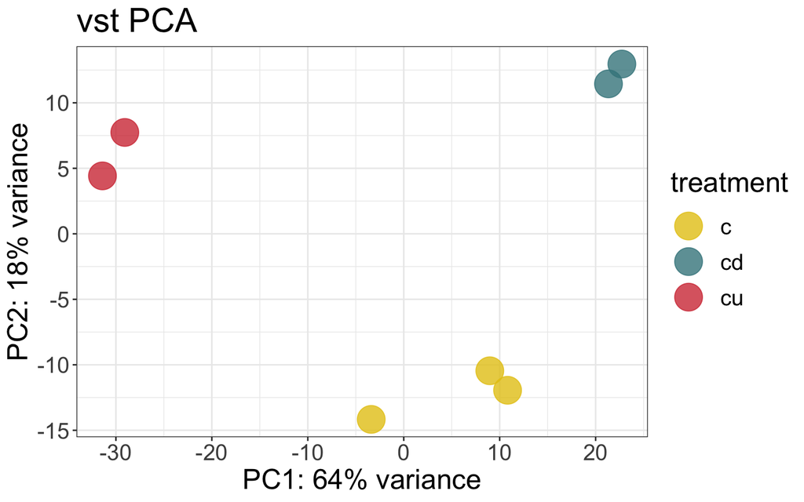

```r
data1 <- plotPCA(vsd, intgroup = "treatment", returnData=TRUE)
data1$group<-gsub(" : ","_",as.character(data1$group))
percentVar1 <- round(100 * attr(data1, "percentVar"))

PCA<-ggplot(data1, aes(PC1, PC2, color = treatment))+ theme_bw()+
  geom_point(size=9, alpha = 0.8) + scale_colour_manual(values = c("#E5C616", "#42858C","#D33B44"))+
  xlab(paste0("PC1: ",percentVar1[1],"% variance")) +
  ylab(paste0("PC2: ",percentVar1[2],"% variance")) +

  theme(text = element_text(size=20)) + ggtitle("vst PCA")
PCA
```

```r
#ggsave("figures/vsd_PCA.png", device="png") # to save the plot
```

## 2.3 HeatMaps

rlog HeatMap (este es el bueno):

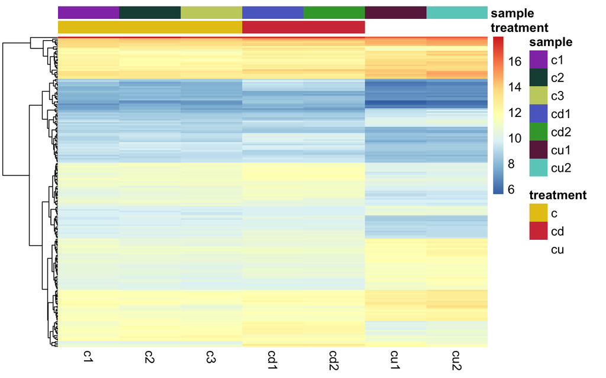

```r
df <- as.data.frame(colData(rld)[,c("treatment", "sample")])

mat_colors1<-list(sample = jcolors("pal8")[0:7])
names(mat_colors1$sample)<- df$sample

mat_colors <- list(treatment = jcolors("pal7")[7:9])
names(mat_colors$treatment) <- c("c", "cd", "cu")

genes <- order(res$padj)[1:200]

phea<-pheatmap(assay(rld)[genes, ], cluster_rows=TRUE, show_rownames=FALSE,
         cluster_cols=FALSE, annotation_col=df, annotation_colors = c(mat_colors1, mat_colors), fontsize = 12)
```

```r
ggsave("heatmap.pdf", device="pdf", width = 9, height = 5)
```

With Rlog transformed data:

```r
library(jcolors)
genes <- order(res$padj)[1:200]

mat <- assay(rld)[genes, ]
mat <- mat - rowMeans(mat)

df <- as.data.frame(colData(rld)[,c("treatment", "sample")])


p<- pheatmap(mat,  cluster_rows=TRUE, cluster_cols=FALSE, show_rownames = FALSE, filename = "heatmap.pdf")
p
```

Same but with variance stabilizing function:

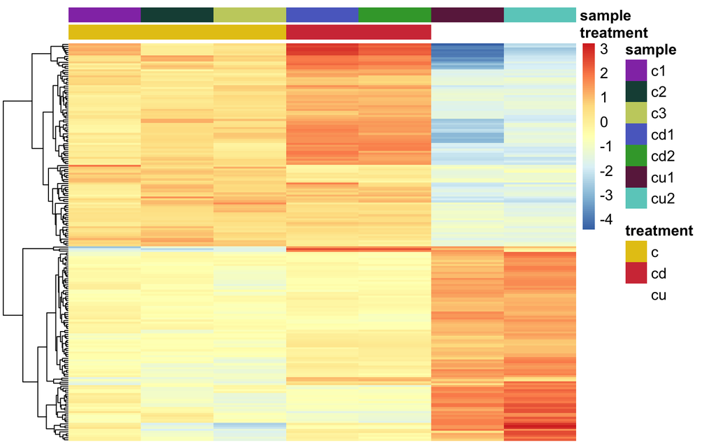

```r
mat <- assay(vsd)[genes, ]
mat <- mat - rowMeans(mat)

df <- as.data.frame(colData(vsd)[,c("treatment", "sample")])

pheatmap(mat,  cluster_rows=TRUE, show_rownames=FALSE, show_colnames = FALSE,
         cluster_cols=FALSE, annotation_col=df, annotation_colors = c(mat_colors1, mat_colors), fontsize = 12)
```

Heatmap of sample-to-sample distances, it can be used instead PCA.

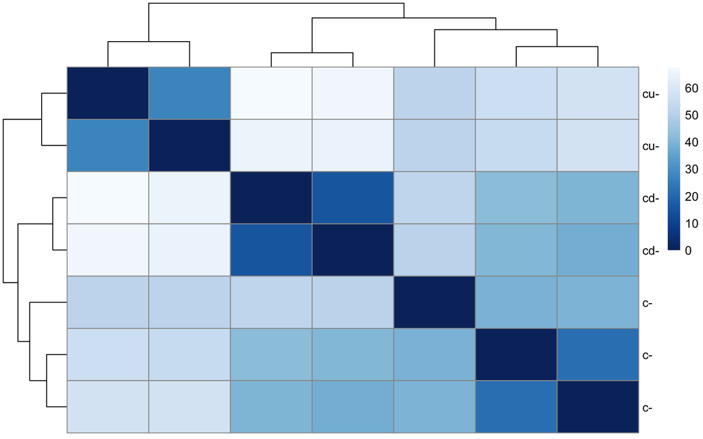

```r
sampleDists <- dist(t(assay(vsd)))
sampleDistMatrix <- as.matrix(sampleDists)
rownames(sampleDistMatrix) <- paste(vsd$treatment, vsd$type, sep="-")
colnames(sampleDistMatrix) <- NULL
colors <- colorRampPalette( rev(brewer.pal(9, "Blues")) )(255)
pheatmap(sampleDistMatrix,
         clustering_distance_rows=sampleDists,
         clustering_distance_cols=sampleDists,
         col=colors)
```

get data frame of DESeq2 results:

```r
cd_table<- data.frame(cd_res) %>%
  rownames_to_column(var = "ensgenes")
cu_table<- data.frame(cu_res) %>%
  rownames_to_column(var = "ensgenes")
```

Check common DEGs between treatments

```r
cadup<- filter(cd_table, (padj< 0.05 & log2FoldChange >= 1))
caddown<- filter(cd_table, (padj< 0.05 & log2FoldChange <= -1))

coup<-filter(cu_table, (padj< 0.05 & log2FoldChange >= 1))
codown<- filter(cu_table, (padj< 0.05 & log2FoldChange <= -1))

up<- bind_rows(cadup, coup)
up_d<-up[up$ensgenes %in% up$ensgenes[duplicated(up$ensgenes)],]

down<- bind_rows(caddown, codown)
down_d<-down[down$ensgenes %in% down$ensgenes[duplicated(down$ensgenes)],]

#keep only the first duplicate
up_d<-up_d %>% distinct(ensgenes, .keep_all = TRUE)
down_d<- down_d %>% distinct(ensgenes, .keep_all = TRUE)
```

## 2.4 Volcano plots colored by significance

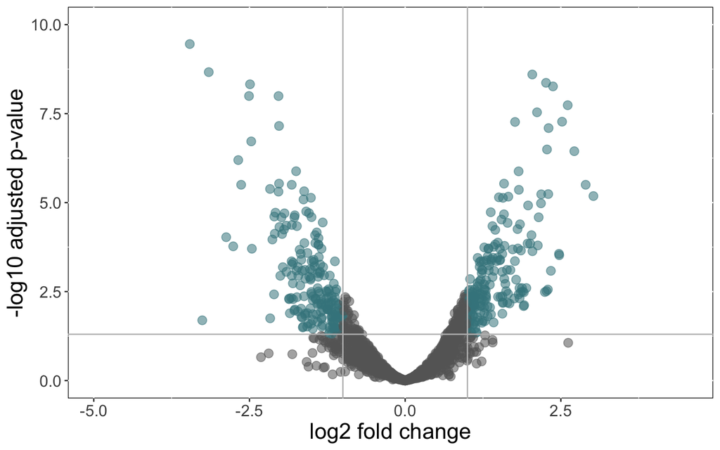

```r
#add a column of NA
cd_table$delabel <- NA
cd_table$delabel[cd_table$diffexpressed != "NO"] <- cd_table$ensgenes[cd_table$diffexpressed != "NO"]


# add a column of NAs
cd_table$diffexpressed <- "NO"
# if log2Foldchange > 1 and pvalue < 0.05, set as "UP"
cd_table$diffexpressed[cd_table$log2FoldChange >= 1 & cd_table$padj < 0.05] <- "GENEDE"
# if log2Foldchange < -0.6 and pvalue < 0.05, set as "DOWN"
cd_table$diffexpressed[cd_table$log2FoldChange <= -1 & cd_table$padj < 0.05] <- "GENEDE"


cdplot<-ggplot(cd_table, aes(x = log2FoldChange, y = -log10(padj), color = diffexpressed, alpha=0.5)) +
  geom_point(size=3) +
  xlab("log2 fold change") +
  ylab("-log10 adjusted p-value") +
  ylim (0,10) +
  theme (panel.background = element_rect (fill = "white", color = "black", linetype= "solid"),
         text = element_text(size=16),
         legend.position = "none",
         plot.title = element_text(size = rel(1.1), hjust = 0.5),
         axis.title = element_text(size = rel(1.1))) +
        geom_vline(xintercept=c(-1, 1), col="grey", size=0.5) +
        geom_hline(yintercept=-log10(0.05), col="grey", size=0.5)

cdplot1 <- cdplot + scale_colour_manual(values = c ("#42858C", "#666666"))


cu_table$diffexpressed <- "NO"
# if log2Foldchange > 1 and pvalue < 0.05, set as "UP"
cu_table$diffexpressed[cu_table$log2FoldChange >= 1 & cu_table$padj < 0.05] <- "GENEDE"
# if log2Foldchange < -0.6 and pvalue < 0.05, set as "DOWN"
cu_table$diffexpressed[cu_table$log2FoldChange <= -1 & cu_table$padj < 0.05] <- "GENEDE"

cuplot<-ggplot(cu_table, aes(x = log2FoldChange, y = -log10(padj), color = diffexpressed, alpha=0.5)) +
  geom_point(size=3) +
  xlab("log2 fold change") +
  ylab("-log10 adjusted p-value") +
  ylim (0,10) +
  theme (panel.background = element_rect (fill = "white", color = "black", linetype= "solid"),
         text = element_text(size=16),
         legend.position = "none",
         plot.title = element_text(size = rel(1.1), hjust = 0.5),
         axis.title = element_text(size = rel(1.1))) +
        geom_vline(xintercept=c(-1, 1), col="grey", size=0.5) +
        geom_hline(yintercept=-log10(0.05), col="grey", size=0.5)

cuplot1 <- cuplot + scale_colour_manual(values = c("#D33B44", "#666666"))


cdplot1
```

```r
ggsave("~/Desktop/Nfcore/volcanocd.pdf", device="pdf", width = 8, height = 5)
```

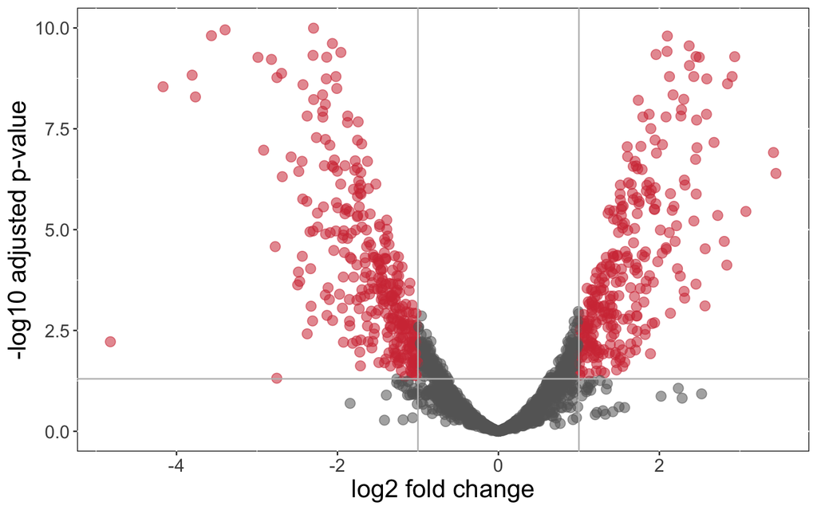

```r
cuplot1
```

```r
ggsave("~/Desktop/Nfcore//volcanocu.pdf", device="pdf", width = 8, height = 5)
```

Prepare list of ensgenes for Venn diagram

```r
Cd_f<- filter(cd_table, (padj< 0.05 & log2FoldChange >= 1) | (padj< 0.05 & log2FoldChange <= -1))
Cdnames<-dplyr::select (Cd_f, c(ensgenes))

Cu_f<- filter(cu_table, (padj< 0.05 & log2FoldChange >= 1) | (padj< 0.05 & log2FoldChange <= -1))
Cunames<-dplyr::select (Cu_f, c(ensgenes))
```

# 3 Gene Set Enrichment Testing

get data frame of DESeq2 results:

```r
cd_table<- data.frame(cd_res) %>%
  rownames_to_column(var = "ensgenes")
cu_table<- data.frame(cu_res) %>%
  rownames_to_column(var = "ensgenes")
```

add annotation table and merge

```r
annot<- read.csv("~/Desktop/Nfcore/nis_annot.csv")
cd_annot<- merge(cd_table, annot, by="ensgenes")
cu_annot<- merge(cu_table, annot, by="ensgenes")

write.csv(cd_annot, file="cd_annot.csv")
write.csv(cu_annot, file="cu_annot.csv")
```

table up and down (P=0.05) for enrichment analysis

```r
#DE Up and Down for padj 0.05 and log2FoldChange 1

CdUp<- cd_annot[cd_annot$padj <= 0.05 & cd_annot$log2FoldChange >= 1, ]
CdUp<-  CdUp[complete.cases(CdUp$ensgenes),]
CdDown<- cd_annot[cd_annot$padj <= 0.05 & cd_annot$log2FoldChange <= -1, ]
CdDown<- CdDown[complete.cases(CdDown$ensgenes), ]
CuUp<- cu_annot[cu_annot$padj <= 0.05 & cu_annot$log2FoldChange >= 1, ]
CuUp<-  CuUp[complete.cases(CuUp$ensgenes),]
CuDown<- cu_annot[cu_annot$padj <= 0.05 & cu_annot$log2FoldChange <= -1, ]
CuDown<-  CuDown[complete.cases(CuDown$ensgenes),]

write.csv(CdUp, file="cd_up_annot.csv")
write.csv(CdDown, file="cd_down_annot.csv")
write.csv(CuUp, file="cu_up_annot.csv")
write.csv(CuDown, file="cu_down_annot.csv")
```

```r
#prepare GO terms from the DEGs for revigo input
CdUp$D <- 1
CdDown$D <- 0.5
CuUp$D <- 1
CuDown$D <- 0.5

#bind
cd_deg<- bind_rows(CdUp, CdDown)
cu_deg<- bind_rows(CuUp, CuDown)

#keep GO lists and put in a single column
cdDE<- cd_deg[ ,c("padj", "GO.IDs", "D")]
cuDE<- cu_deg[ ,c("padj", "GO.IDs", "D")]

GOcd<- cdDE %>%
    separate(GO.IDs, c("a", "b", "c", "d", "e", "f", "g", "h"), ";")
gocdmelt <- melt(GOcd, id = c("padj", "D"))
cdmeltclean<- gocdmelt[ ,c("padj", "value", "D")]

GOcu<- cuDE %>%
    separate(GO.IDs, c("a", "b", "c", "d", "e", "f", "g", "h"), ";")
gocumelt <- melt(GOcu, id = c("padj", "D"))
cumeltclean<- gocumelt[ ,c("padj", "value", "D")]

#remove empty rows
cdnona <- cdmeltclean[!(is.na(cdmeltclean$value) | cdmeltclean$value==""), ]
cunona <- cumeltclean[!(is.na(cumeltclean$value) | cumeltclean$value==""), ]

#remove first characters of the column value
cdnona$value <- substring(cdnona$value, 3)
cunona$value <- substring(cunona$value, 3)

#rename
names(cdnona)[2] <- "GO"
names(cunona)[2] <- "GO"

#save
write.csv(cdnona, "~/Desktop/Nfcore/goinputcd.csv")
write.csv(cunona, "~/Desktop/Nfcore/goinputcu.csv")
```

COn mis datos

```r
goframe<- read.csv("~/Desktop/Nfcore/goframe.csv")
colnames(goframe)
```

```
## [1] "GO"       "evidence" "isoform"
```

```r
head(goframe)
```

```
##                                               GO evidence
## 1             GO:0007155; GO:0030001; GO:0046872      ISS
## 2                         GO:0030001; GO:0046872      ISS
## 3 GO:0005887; GO:0042626; GO:0043190; GO:0055085      ISS
## 4 GO:0005887; GO:0042626; GO:0043190; GO:0055085      ISS
## 5                         GO:0005524; GO:0016887      ISS
## 6                                                     ISS
##                          isoform
## 1   fig|387092.6.peg.26|NIS_0024
## 2  fig|387092.6.peg.362|NIS_0350
## 3   fig|387092.6.peg.25|NIS_0023
## 4  fig|387092.6.peg.360|NIS_0348
## 5  fig|387092.6.peg.361|NIS_0349
## 6 fig|387092.6.peg.1771|NIS_1694
```

```r
goframesep<- goframe %>%
    separate(GO, c("a", "b", "c", "d", "e", "f", "g", "h"), ";")
```

```r
goframesep2<- goframesep %>%
    separate(isoform, c("fig", "code", "old_locus"), "\\|")
goframesep3<-goframesep2[, -c(10:11)]
goframemelt <- melt(goframesep3, id = c("evidence","old_locus"))
goframemelt<- goframemelt[, -3]
colnames(goframemelt)
```

```
## [1] "evidence"  "old_locus" "value"
```

```r
names(goframemelt)[names(goframemelt)=="value"]<- "GO"
goframemelt<- goframemelt[, c(3, 1, 2)]

goframeData = data.frame(goframemelt$GO, goframemelt$evidence, goframemelt$old_locus)
names(goframeData) = c("GO", "Evidence", "old_locus")
goframeData$GO <- as.character(goframeData$GO)
goframeData$Evidence <- as.character(goframeData$Evidence)
goframeData$old_locus <- as.character((goframeData$old_locus))
head(goframeData)
```

```
##           GO Evidence old_locus
## 1 GO:0007155      ISS  NIS_0024
## 2 GO:0030001      ISS  NIS_0350
## 3 GO:0005887      ISS  NIS_0023
## 4 GO:0005887      ISS  NIS_0348
## 5 GO:0005524      ISS  NIS_0349
## 6                 ISS  NIS_1694
```

```r
goframeData <- na.omit(goframeData)

universe<- goframeData[ ,3]

CdUpnames<- CdUp[ ,13]
CdUpnames<-as.character(CdUpnames)


CdDownnames<- CdDown[ ,13]
CdDownnames<-as.character(CdDownnames)

CuUpnames<- CuUp[ ,13]
CuUpnames<-as.character(CuUpnames)

CuDownnames<- CuDown[ ,13]
CuDownnames<-as.character(CuDownnames)
```

Now turn this into a GO frame for GOstats:

```r
goFrame<- GOFrame(goframeData)
goAllFrame<- GOAllFrame(goFrame)
gsc <- GeneSetCollection(goAllFrame, setType = GOCollection())
```

```r
params<- GSEAGOHyperGParams(name="NIS, C vs. Cd", geneSetCollection= gsc, geneIds = CuDownnames, universeGeneIds = universe, ontology = "BP", pvalueCutoff = 0.05, conditional = TRUE, testDirection = "over")
#modify the function for each dataset (i.e. CdUp, CdDown, CuUp, CuDown)

Over<- hyperGTest(params)

Over
```

```
## Gene to GO BP Conditional test for over-representation
## 156 GO BP ids tested (4 have p < 0.05)
## Selected gene set size: 32
##     Gene universe size: 210
##     Annotation package: Based on a GeneSetCollection Object
```

```r
summary(Over)
```

```
##       GOBPID       Pvalue OddsRatio ExpCount Count Size
## 1 GO:0050789 0.0005313790  4.349794 6.247619    14   41
## 2 GO:0007165 0.0009975193  4.656085 4.419048    11   29
## 3 GO:0050896 0.0037399172  3.507692 5.790476    12   38
## 4 GO:0000160 0.0083454488  3.904762 3.352381     8   22
##                                      Term
## 1        regulation of biological process
## 2                     signal transduction
## 3                    response to stimulus
## 4 phosphorelay signal transduction system
```

```r
CuDownBP<- summary(Over)


#Add a column with the element info and ontoly type (BP or MF)
#CdUpBP$ontology<-"BP"
#CdUpBP$DE<-"Up"
#CdUpBP$elem<- "Cd"

#CdDownBP$ontology<-"BP"
#CdDownBP$DE<-"Down"
#CdDownBP$elem<- "Cd"

#CuUpBP$ontology<-"BP"
#CuUpBP$DE<-"Up"
#CuUpBP$elem<- "Cu"

#CuDownBP$ontology<-"BP"
#CuDownBP$DE<-"Down"
#CuDownBP$elem<- "Cu"


#repeat the same but with MF (molecular function)
#params<- GSEAGOHyperGParams(name="NIS, C vs. Cd", geneSetCollection= gsc, geneIds = CuDownnames, universeGeneIds = universe, ontology = "MF", pvalueCutoff = 0.05, conditional = TRUE, testDirection = "over")

#modify the function for each dataset (i.e. CdUp, CdDown, CuUp, CuDown)

#Over<- hyperGTest(params)

#Over

#summary(Over)

#CuDownMF<- summary(Over)

#keep playing with th ontology and geneIDs parameters

#Add a column with the element info and ontoly type (BP or MF)
#CdUpMF$ontology<-"MF"
#CdUpMF$DE<-"Up"
#CdUpMF$elem<- "Cd"

#CdDownMF$ontology<-"MF"
#CdDownMF$DE<-"Down"
#CdDownMF$elem<- "Cd"

#CuUpMF$ontology<-"MF"
#CuUpMF$DE<-"Up"
#CuUpMF$elem<- "Cu"

#CuDownMF$ontology<-"MF"
#CuDownMF$DE<-"Down"
#CuDownMF$elem<- "Cu"

#bind all the tables to have all the results together
#GOresBP<- rbind(CdUpBP, CdDownBP, CuUpBP, CuDownBP)
#GOresMF<- rbind(CdUpMF, CdDownMF, CuUpMF, CuDownMF)

#names(GOresBP)[names(GOresBP) == "GOBPID"] <- "GO_id"
#names(GOresMF)[names(GOresMF) == "GOMFID"] <- "GO_id"

#GOres<- rbind(GOresBP, GOresMF)

#write.csv(GOres, "~/Desktop/Nfcore/GOres.csv")
```

Preparamos la lista de genes, necesitamos nis del resto

```r
cdupinpu<- CdUp[ ,15]
cdupinput<-as.vector(cdupinpu)

cddowninpu<- CdDown[ ,15]
cddowninput<-as.vector(cddowninpu)

cuupinpu<- CuUp[ ,14]
cuupinput<-as.vector(cuupinpu)

cudowninpu<- CuDown[ ,14]
cudowninput<-as.vector(cuupinpu)
```

KEGG analysis using kegga function

```r
cdupkeggs<- kegga(cdupinput, species.KEGG = "nis")
cddownkeggs<- kegga(cddowninput, species.KEGG = "nis")
cuupkeggs<- kegga(cuupinput, species.KEGG = "nis")
cudownkeggs<- kegga(cudowninput, species.KEGG = "nis")
```